# ANOVA

Jordan Golubov y José Arévalo

2026-04-16

- El ANOVA de una vía se utiliza para probar si tres o más promedios poblacionales son iguales.
- Es una extensión de la prueba de $t$ de medidas independientes

#### Variable de respuesta

La variable de respuesta es la variable que se va a comparar.

#### Factores y niveles

Ejemplo:

Tenemos las alturas de las personas del salón divididas en el **factor usa lentes**. El factor usa lentes a su vez tiene **2 niveles**: usa lentes y no usa lentes}. La variable dependiente (la y) es la altura y la variable independiente (la x) es si usa o no lentes

El factor puede tener más de dos niveles por ejemplo: usa lentes físicos, lentes de contacto y no usa lentes.

La hipótesis nula, $H_0$, asume que las alturas son iguales:

$${a} = {b} = {c}$$

Esto quiere decir que no hay diferencias en las alturas entre los miembros del salón que usan lentes, usan lentes de contacto y no usan lentes

La hipótesis alternativa, $H_1$ es entonces que alguno es diferente.

#### Ejemplo (hipotético)

La clase la podemos dividir en los alumnos que quieren aprender, los que hacen el mínimo esfuerzo y los indiferentes. Vamos a suponer que estos tres niveles afectan la calificación en un examen.

El ANOVA no prueba si un promedio es mayor o menor a otros, sino si son iguales o diferentes:

$$\mu_{atencion} = \mu_{min. esfuerzo} =
\mu_{indif}$$

Tomamos una muestra de alumnos de cada tipo a los cuales se les aplicó un examen de conocimientos elementales de **R** con los siguientes resultados:

```r
Esfuerzo <- c(87, 82, 83, 97, 93, 91, 55, 67, 53, 83, 78, 68, 77, 64, 71, 69, 61, 63, 38, 59, 55, 66, 45, 52, 52, 61, 65)
length(Esfuerzo)
```

```
## [1] 27
```

```r
Nivel.atencion <- rep(c('Atencion', 'Minimo.esfuerzo', 'Indiferentes'), each=9)
datos.atencion <- data.frame(Nivel.atencion,Esfuerzo)
datos.atencion
```

```
##     Nivel.atencion Esfuerzo
## 1         Atencion       87
## 2         Atencion       82
## 3         Atencion       83
## 4         Atencion       97
## 5         Atencion       93
## 6         Atencion       91
## 7         Atencion       55
## 8         Atencion       67
## 9         Atencion       53
## 10 Minimo.esfuerzo       83
## 11 Minimo.esfuerzo       78
## 12 Minimo.esfuerzo       68
## 13 Minimo.esfuerzo       77
## 14 Minimo.esfuerzo       64
## 15 Minimo.esfuerzo       71
## 16 Minimo.esfuerzo       69
## 17 Minimo.esfuerzo       61
## 18 Minimo.esfuerzo       63
## 19    Indiferentes       38
## 20    Indiferentes       59
## 21    Indiferentes       55
## 22    Indiferentes       66
## 23    Indiferentes       45
## 24    Indiferentes       52
## 25    Indiferentes       52
## 26    Indiferentes       61
## 27    Indiferentes       65
```

Ahora podemos separar la información del dataframe.

```r
tamanio.muestra <- tapply(datos.atencion$Esfuerzo, datos.atencion$Nivel.atencion, length)
promedio.por.tipo <- tapply(datos.atencion$Esfuerzo, datos.atencion$Nivel.atencion, mean)
varianza.por.tipo <- tapply(datos.atencion$Esfuerzo, datos.atencion$Nivel.atencion, var)
desv.est.por.tipo <- tapply(datos.atencion$Esfuerzo, datos.atencion$Nivel.atencion, sd)

tamanio.muestra
```

```
##        Atencion    Indiferentes Minimo.esfuerzo
##               9               9               9
```

```r
promedio.por.tipo
```

```
##        Atencion    Indiferentes Minimo.esfuerzo
##        78.66667        54.77778        70.44444
```

```r
varianza.por.tipo
```

```
##        Atencion    Indiferentes Minimo.esfuerzo
##       268.50000        84.94444        56.52778
```

```r
desv.est.por.tipo
```

```
##        Atencion    Indiferentes Minimo.esfuerzo
##       16.385970        9.216531        7.518496
```

La suma de cuadrados básicamente nos habla de la diferencia entre el promedio y el valor.

**¿Son los valores idénticos?**

No, hay cierta variación en los datos. A esto se le denomina el *total de la variación* o **SC(Total)**.

**¿Son los promedios idénticos?**

No, hay cierta variacón entre los grupos. A esto se le denomina la *variación entre grupos* descrito como **SS(B)** que significa la suma de cuadrados (variación) entre los grupos.

**¿Es cada valor dentro de cada grupo idéntico?**

No, hay cierta variación dentro de los grupos o llamada variación dentro de los grupos. Se le denomina la *variación del error* **SS(W)** que significa la suma de cuadrados (variación) dentro de grupos.

#### Entonces podemos encontrar dos fuentes de variación:

- La variación entre grupos SS(B) o la variación debida al factor
- La variación dentro de grupos SS(W) o la variación que no puede ser explicada por el factor también llamada el error

La media general es el promedio de todos los valores cuando se ignora el factor

$$\overline{x} =
\frac{\sum{\overline{x}}_{i}}{n_{i}}$$

En nuestro caso, queremos tener en cuenta el factor por lo que tenemos un promedio

$$\overline{x} =
\frac{n_{1}\overline{x}_{1} +
n_{2}\overline{x}_{2}+...+n_{k}\overline{x}_{k}}{n_{1} +
n_{2}+...+n_{k}}$$

#### En el ejemplo

```r
promedio.ponderado <- sum((tamanio.muestra * promedio.por.tipo))/sum(tamanio.muestra)
promedio.ponderado
```

```
## [1] 67.96296
```

La variación entre grupos es la variación entre el promedio de cada muestra y el promedio general. Cada variación individual se pondera por el tamaño de muestra.

$$SS(B) = \sum_{i=1}^{k} n_{i}
(\overline{x}_{i} - \overline{x})^{2}$$

$$SS(B) = n_{1}(\overline{x}_{1} -
\overline{x})^{2} + n_{2}(\overline{x}_{2} - \overline{x})^{2} +... +
n_{k}(\overline{x}_{k} - \overline{x})^{2}$$

#### Para nuestro ejemplo:

```r
levels(datos.atencion$Nivel.atencion)
```

[output not shown]

```r
atencion <- subset(datos.atencion, datos.atencion=='Atencion')
indiferente <- subset(datos.atencion, datos.atencion=='Indiferentes')
minimo.esfuerzo <- subset(datos.atencion, datos.atencion=='Minimo.esfuerzo')

variacion.entre.grupos <- (9*((promedio.por.tipo[1]-mean(datos.atencion$Esfuerzo))^2)) + (9*((promedio.por.tipo[2]-mean(datos.atencion$Esfuerzo))^2)) +
  (9*((promedio.por.tipo[3]-mean(datos.atencion$Esfuerzo))^2))
variacion.entre.grupos
```

```
## Atencion
## 2651.185
```

```r
varianza.B <- variacion.entre.grupos
```

## Variación dentro de grupos

La variación dentro de grupos es el total ponderado de las variaciones individuales. El ponderado se realiza por medio de los grados de libertad. Los grados de libertad de cada grupo es tamaño de muestra de ese nivel de factor $-$ 1.

$$SS(W) = \sum_{i=1}^{k} df_{i}
s_{i}^{2}$$

$$ss(W) = df_{1} s_{1}^{2} + df_{2}
s_{2}^{2} +...+df_{k} s_{k}^{2}$$

```r
varianza.w <- (varianza.por.tipo[1]*8) + (varianza.por.tipo[2]*8) + (varianza.por.tipo[3]*8)
varianza.w
```

```
## Atencion
## 3279.778
```

## SS Total

SS total es el total de la variación, que básicamente es la suma de la SS entre y SS dentro de los grupos.

```r
SS.total <- varianza.w + varianza.B
SS.total
```

```
## Atencion
## 5930.963
```

Los grados de libertad son el número de valores $-$ 1.

Si tenemos tres grupos entonces:

```r
df.B <- 2
```

Grados de libertad dentro de grupos es la suma de los gl (df) de cada grupo

Los tamaños de muestra son; 9, 9 y 9 \

```r
df.W. <- 8 + 8 + 8
df.W.
```

```
## [1] 24
```

```r
df.Total <- 27 - 1
df.Total
```

```
## [1] 26
```

## Varianzas

Las varianzas también se llaman el *cuadrado medio* (**MS** o **CM**).

Son el promedio de las desviaciones del promedio cuadrados y se obtienen dividiendo la variación entre los grados de libertad.

$$MS = \frac{SS}{df}$$

$$Varianza =
\frac{Variacion}{df}$$

Note que el **MS(Total)** no es la suma de **MS(B)** y **MS(W)**.

Por lo general no utilizamos el **MS(Total)**.

```r
MS.B <- varianza.B/df.B
MS.W <- varianza.w/df.W.
MS.Tot <- SS.total/df.Total
MS.B
```

```
## Atencion
## 1325.593
```

```r
MS.W
```

```
## Atencion
## 136.6574
```

```r
MS.Tot
```

```
## Atencion
##  228.114
```

## El estadístico F

El estadístico F es la razón entre la varianza de dos muestras.

EL MS(B) y MS(W) son las varianzas de las muestras y es lo que dividimos.

```r
F <- MS.B/MS.W
F
```

```
## Atencion
## 9.700115
```

## Ahora usemos la versión corta en **R**

```r
anova.esfuerzo <- aov(datos.atencion$Esfuerzo~datos.atencion$Nivel.atencion)
anova(anova.esfuerzo)
```

```
## Analysis of Variance Table
##
## Response: datos.atencion$Esfuerzo
##                               Df Sum Sq Mean Sq F value    Pr(>F)
## datos.atencion$Nivel.atencion  2 2651.2 1325.59  9.7001 0.0008178 ***
## Residuals                     24 3279.8  136.66
## ---
## Signif. codes:  0 '***' 0.001 '**' 0.01 '*' 0.05 '.' 0.1 ' ' 1
```

### Prueva de diferencias entre las medias, Tukey test.

```r
TukeyHSD(anova.esfuerzo)
```

```
##   Tukey multiple comparisons of means
##     95% family-wise confidence level
##
## Fit: aov(formula = datos.atencion$Esfuerzo ~ datos.atencion$Nivel.atencion)
##
## $`datos.atencion$Nivel.atencion`
##                                    diff        lwr        upr     p adj
## Indiferentes-Atencion        -23.888889 -37.650802 -10.126976 0.0006375
## Minimo.esfuerzo-Atencion      -8.222222 -21.984135   5.539691 0.3123719
## Minimo.esfuerzo-Indiferentes  15.666667   1.904754  29.428580 0.0235373
```

#### Gráficos de las diferencias entre las medias.

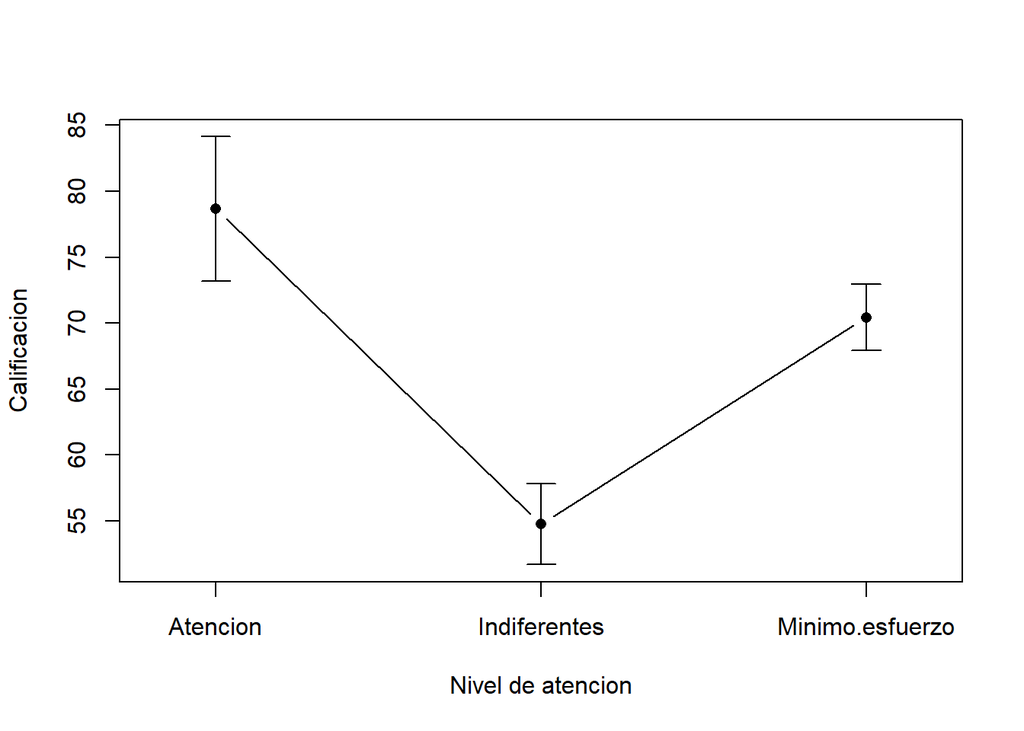

```r
lineplot.CI(x.factor = Nivel.atencion, response = Esfuerzo, data = datos.atencion, xlab = 'Nivel de atencion', ylab = 'Calificacion')
```